# News Sources and Vaccination Hesitancy

Theresa Winner

2023-03-15

```r
library(sjPlot)
library(ggpubr)
library(tidyverse)
library(dplyr)
library(jtools)
library(ggeffects)
library(ggplot2)
library(maps)
library(readr)
library(tidyverse)
library(dplyr)
library(modelsummary)
```

# Read and prepare data

Create dataset for september (created one folder with all september datasets)

```r
# list_of_files <- list.files(path = "data_september", recursive = TRUE, pattern = "\\.csv$", full.names = TRUE)
# df <- read_csv(list_of_files, id = "file_name")
# df$RecordedDate <- as.character(df$RecordedDate)
#
# # 1st September has more variables (298) than the rest of September -> read them separately and put them together
# first_sept <- read.csv("2021-09-01_full.csv")
# df <- bind_rows(first_sept, df)
#
# # Save september data as new file
# library(data.table)
# fwrite(df, "september_dt.csv")
```

Read september data

```r
dt_sept <- read.csv("september_dt.csv")
```

Prepare Country-Codes and assign UN-Geoscheme to countries (https://en.wikipedia.org/wiki/United_Nations_geoscheme_for_Europe) -> without Russia as it is mostly in Asia

```r
country <- read.csv("CTIS_survey_country_region_map_table_ver1.083021.csv")

country_eu <- country %>%
  mutate(europe_part = case_when(country_region %in% c("Belarus", "Bulgaria", "Czech Republic", "Hungary",
                                                       "Poland", "Moldova", "Romania", "Slovakia",
                                                       "Ukraine") ~ "East",
                                 country_region %in% c("Aland Islands", "Denmark", "Estonia", "Faroe Islands",
                                                       "Finland", "Iceland", "Ireland", "Isle Of Man", "Latvia",
                                                       "Lithuania","Norway", "Svalbard and Jan Mayen", "Sweden",
                                                       "United Kingdom") ~ "North",
                                 country_region %in% c("Albania", "Andorra", "Bosnia and Herzegovina", "Croatia",
                                                       "Gibraltar", "Greece", "Italy", "Vatican City", "Malta",
                                                       "Montenegro", "Republic of North Macedonia", "Portugal",
                                                       "San Marino", "Serbia", "Slovenia", "Spain") ~ "South",
                                 country_region %in% c("Austria", "Belgium", "France", "Germany",
                                                       "Liechtenstein", "Luxembourg", "Monaco", "Netherlands",
                                                       "Switzerland") ~ "West")) %>%
  filter(!is.na(europe_part))

country_eu <- country_eu[, c("country_region_numeric", "country_region", "europe_part")]
country_num <- country_eu$country_region_numeric
```

Select only countries in Europe and important variables:  
- B0: Ever had COVID-19  
- B7: Have you been tested for COVID-19 in last days?  
- B8a: Did your most recent test find, that you had COVID-19?  
- V1 & V2: Have you had a vaccination & how many?  
- V15a: Have you an appointment for vaccination?  
- V3a: If you have the chance to get a vaccination, would you choose it?  
- V5c: Reasons that you only probably would choose to get a Covid vaccination  
- C0a: Past 24 hours have you done anything of the following  
- G1: How much do you worry about getting COVID19?  
- H3: How many of your friends and family have gotten a COVID vaccination?  
- I5: Where have you received news in the last 7 days? Local health workers, scientist, who, governement/officials,  
politicians, journalists, friends & family, religious leaders, none  
- I6: How much do you trust news sources?  
- E3: Gender  
- E4: Age  
- E8: Highest level of education  
- E2: area (city, town, village)

```r
dt_sept_eu <- dt_sept %>%
  filter(A2_2_1 %in% country_num) %>%
  dplyr::select(survey_region, A2_2_1, B0, B7, B8a, V1, V2, V15a, V3a, V5c_1, V5c_2, V5c_3, V5c_4, V5c_5, V5c_6,
                V5c_7, V5c_8, V5c_9, V5c_10, C0a_1, C0a_2, C0a_3, C0a_4, C0a_5, C0a_6, C0a_7, G1, H3, I5_1, I5_2,
                I5_3, I5_4, I5_5, I5_6, I5_7, I5_8, I5_9, I6_1, I6_2, I6_3, I6_4, I6_5, I6_6, I6_7, I6_8, E3,
                E4, E8, E2) %>%
  mutate_all(na_if, -99) %>%
  mutate_all(na_if, -88) %>%
  mutate_all(na_if, -77)
```

Change vaccination-variable to a binary variable with 0 (No) and 1 (Yes) and mark people who didn’t want to say their gender with “NA”

```r
dt_sept_eu$V1[dt_sept_eu$V1 == 3] <- NA
dt_sept_eu$V1[dt_sept_eu$V1 == 2] <- 0

dt_sept_eu$E3[dt_sept_eu$E3 == 4] <- NA
```

Assign geoscheme of europe to september dataset

```r
names(dt_sept_eu)[names(dt_sept_eu) == "A2_2_1"] <- "country_region_numeric"
dt_sept_eu <- merge(dt_sept_eu, country_eu, by = "country_region_numeric")
```

Group variables in (binary) variables for regression models and rename variables:  
- One age variable with three groups (18-34, 35-64, $\geq$ 65) and one with two (< 55, $\geq$ 55)  
- Gender in male and female  
- Education in school- and university education  
- Vaccinationrate in friendsgroup in two groups (Few and most friends)  
- Worried about catching COVID-19 (No, Strongly)  
- Area in urban and rural  
- All trust variables in trust and no trust

```r
dt_sept_eu <- dt_sept_eu %>%
  mutate(age_grouped = case_when(E4 %in% c(1, 2) ~ "1", E4 %in% c(3, 4, 5) ~ "2", E4 %in% c(6, 7) ~ "3")) %>%
  mutate(age_dummy_grouped = case_when(E4 %in% c(1, 2, 3, 4) ~ "0", E4 %in% c(5, 6, 7) ~ "1")) %>%
  mutate(gender_grouped = case_when(E3 %in% c(1) ~ "0", E3 %in% c(2) ~ "1", E3 %in% c(3) ~ NA_character_)) %>%
  mutate(education_grouped = case_when(E8 %in% c(1, 2, 3, 4, 5) ~ "0", E8 %in% c(6, 7) ~ "1")) %>%
  mutate(vacc_friends_grouped = case_when(H3 %in% c(1, 2) ~ "0", H3 %in% c(3, 4, 5) ~ "1")) %>%
  mutate(worry_grouped = case_when(G1 %in% c(3, 4) ~ "0", G1 %in% c(1, 2) ~ "1")) %>%
  mutate(area_grouped = case_when(E2 %in% c(1, 2) ~ "0", E2 %in% c(3) ~ "1")) %>%
  mutate(trust_loc_group = case_when(I6_1 %in% c(1) ~ "0", I6_1 %in% c(2, 3) ~ "1")) %>%
  mutate(trust_science_group = case_when(I6_2 %in% c(1) ~ "0", I6_2 %in% c(2, 3) ~ "1")) %>%
  mutate(trust_who_group = case_when(I6_3 %in% c(1) ~ "0", I6_3 %in% c(2, 3) ~ "1")) %>%
  mutate(trust_gov_group = case_when(I6_4 %in% c(1) ~ "0", I6_4 %in% c(2, 3) ~ "1")) %>%
  mutate(trust_pol_group = case_when(I6_5 %in% c(1) ~ "0", I6_5 %in% c(2, 3) ~ "1")) %>%
  mutate(trust_journalist_group = case_when(I6_6 %in% c(1) ~ "0", I6_6 %in% c(2, 3) ~ "1")) %>%
  mutate(trust_fam_group = case_when(I6_7 %in% c(1) ~ "0", I6_7 %in% c(2, 3) ~ "1")) %>%
  mutate(trust_religious_group = case_when(I6_8 %in% c(1) ~ "0", I6_8 %in% c(2, 3) ~ "1")) %>%
  mutate(B0 = case_when(B0 %in% c(1) ~ "1", I6_8 %in% c(2) ~ "0")) %>%
  mutate(V2 = case_when(V2 %in% c(1) ~ "0", V2 %in% c(2) ~ "1", V2 %in% c(3) ~ NA_character_))

dt_sept_eu <- dt_sept_eu %>%
  rename( "cov_inf" =  B0, "test_cov" = B7, "vacc" = V1,"numb_vacc" = V2,
          "appointment_vacc" = V15a, "worry_cov" = G1, "vacc_friends" = H3,
          "news_loc" = I5_1, "news_science" = I5_2, "news_who" = I5_3, "news_gov" = I5_4,
          "news_pol" = I5_5, "news_journalist" = I5_6, "news_fam" = I5_7, "news_religious" = I5_8,
          "news_none" = I5_9, "trust_loc" = I6_1, "trust_science" = I6_2, "trust_who" = I6_3, "trust_gov" = I6_4,
          "trust_pol" = I6_5, "trust_journalist" = I6_6, "trust_fam" = I6_7, "trust_religious" = I6_8,
          "gender" = E3, "age" = E4, "education" = E8, "area" = E2)
```

Factorize all categorical variables

```r
dt_sept_eu$age_grouped <- as.factor(dt_sept_eu$age_grouped)
# levels(dt_eu$europe_part) <- c("East", "North", "South", "West")
dt_sept_eu$area <- as.factor(dt_sept_eu$area)
dt_sept_eu$trust_loc <- as.factor(dt_sept_eu$trust_loc)
dt_sept_eu$trust_science <- as.factor(dt_sept_eu$trust_science)
dt_sept_eu$trust_who <- as.factor(dt_sept_eu$trust_who)
dt_sept_eu$trust_gov <- as.factor(dt_sept_eu$trust_gov)
dt_sept_eu$trust_pol <- as.factor(dt_sept_eu$trust_pol)
dt_sept_eu$trust_journalist <- as.factor(dt_sept_eu$trust_journalist)
dt_sept_eu$trust_fam <- as.factor(dt_sept_eu$trust_fam)
dt_sept_eu$trust_religious <- as.factor(dt_sept_eu$trust_religious)

dt_sept_eu$trust_loc_group <- as.factor(dt_sept_eu$trust_loc_group)
dt_sept_eu$trust_science_group <- as.factor(dt_sept_eu$trust_science_group)
dt_sept_eu$trust_who_group <- as.factor(dt_sept_eu$trust_who_group)
dt_sept_eu$trust_gov_group <- as.factor(dt_sept_eu$trust_gov_group)
dt_sept_eu$trust_pol_group <- as.factor(dt_sept_eu$trust_pol_group)
dt_sept_eu$trust_journalist_group <- as.factor(dt_sept_eu$trust_journalist_group)
dt_sept_eu$trust_fam_group <- as.factor(dt_sept_eu$trust_fam_group)
dt_sept_eu$trust_religious_group <- as.factor(dt_sept_eu$trust_religious_group)
dt_sept_eu$age_dummy_grouped <- as.factor(dt_sept_eu$age_dummy_grouped)
dt_sept_eu$gender_grouped <- as.factor(dt_sept_eu$gender_grouped)
dt_sept_eu$area_grouped <- as.factor(dt_sept_eu$area_grouped)
dt_sept_eu$education_grouped <- as.factor(dt_sept_eu$education_grouped)
dt_sept_eu$cov_inf <- as.factor(dt_sept_eu$cov_inf)
dt_sept_eu$vacc_friends_grouped <- as.factor(dt_sept_eu$vacc_friends_grouped)

dt_sept_eu$news_loc <- as.factor(dt_sept_eu$news_loc)
dt_sept_eu$news_science <- as.factor(dt_sept_eu$news_science)
dt_sept_eu$news_who <- as.factor(dt_sept_eu$news_who)
dt_sept_eu$news_gov <- as.factor(dt_sept_eu$news_gov)
dt_sept_eu$news_pol <- as.factor(dt_sept_eu$news_pol)
dt_sept_eu$news_journalist <- as.factor(dt_sept_eu$news_journalist)
dt_sept_eu$news_fam <- as.factor(dt_sept_eu$news_fam)
dt_sept_eu$news_religious <- as.factor(dt_sept_eu$news_religious)
dt_sept_eu$news_none <- as.factor(dt_sept_eu$news_none)
```

## Map for european geoscheme:

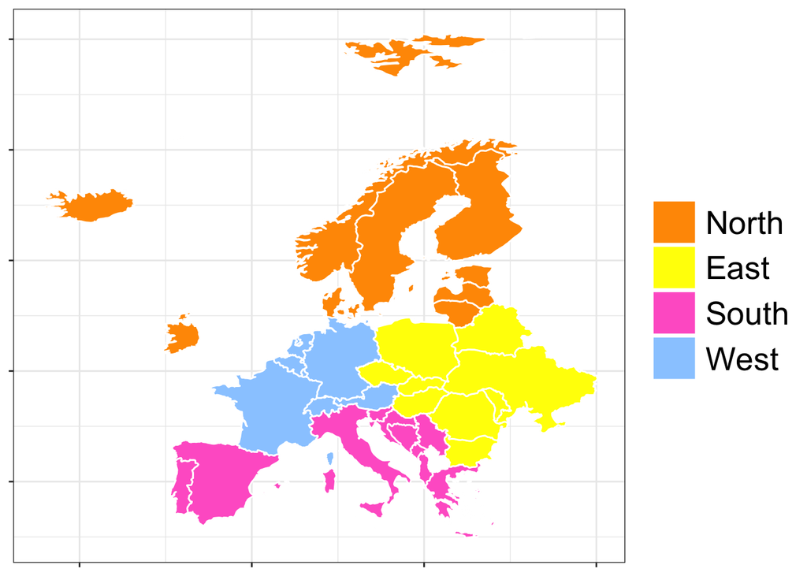

```r
europe_map <- map_data("world", region = unique(dt_sept_eu$country_region))
region_data <- europe_map %>%
  group_by(region) %>%
  summarise(long = mean(long), lat = mean(lat))

names(country_eu)[names(country_eu) == "country_region"] <- "region"
europe_map <- left_join(country_eu, europe_map, by = "region")

mycoleuropa <- c("#FF9900", "#FFFF00", "#FF66CC", "#99CCFF")
europe_map$europe_part <- factor(europe_map$europe_part, levels = c("North", "East", "South", "West"))

ggplot(europe_map, aes(long, lat, group = group))+
  geom_polygon(fill = "lightgray", color = "grey95", linewidth = 0.2) +
  geom_polygon(aes(fill = europe_part), color = "white") +
  scale_fill_manual(values = mycoleuropa, na.value = "grey90") +
  labs(x = "Longitude", y = "Latitude") +
  theme_bw() +
  theme(axis.text.x = element_blank(),
      axis.text.y = element_blank(),
      axis.title.x = element_blank(),
      axis.title.y = element_blank(),
      legend.text = element_text(size = 20),
      legend.title = element_blank(),
      legend.key.size = unit(1, "cm"))
```

# Model with news- and trust-variables as covariables

## Generalized Linear Model with Logit-Link function

Using the trust- & news-variables, gender, area, education, worried about catching COVID-19, had a COVID-19 infection, the area and the part of europe they live in and the number of vaccinated friends as covariables

Model with ungrouped variables:

```r
mod_log_full <- glm(vacc ~ news_loc + news_science + news_who + news_gov + news_pol + news_journalist + news_fam
                          + news_religious + news_none + trust_loc + trust_science + trust_who + trust_gov
                          + trust_pol + trust_journalist + trust_fam + trust_religious + gender + age_grouped
                          + area + education_grouped + cov_inf + worry_cov + vacc_friends_grouped + europe_part,
                    family = binomial(), data = dt_sept_eu)
summary(mod_log_full)
```

```
##
## Call:
## glm(formula = vacc ~ news_loc + news_science + news_who + news_gov +
##     news_pol + news_journalist + news_fam + news_religious +
##     news_none + trust_loc + trust_science + trust_who + trust_gov +
##     trust_pol + trust_journalist + trust_fam + trust_religious +
##     gender + age_grouped + area + education_grouped + cov_inf +
##     worry_cov + vacc_friends_grouped + europe_part, family = binomial(),
##     data = dt_sept_eu)
##
## Deviance Residuals:
##     Min       1Q   Median       3Q      Max
## -3.2759   0.1729   0.2983   0.5107   2.6557
##
## Coefficients:
##                        Estimate Std. Error z value Pr(>|z|)
## (Intercept)           -0.886232   0.077541 -11.429  < 2e-16 ***
## news_loc1              0.004439   0.025508   0.174 0.861843
## news_science1         -0.220391   0.024955  -8.832  < 2e-16 ***
## news_who1             -0.110617   0.027608  -4.007 6.16e-05 ***
## news_gov1              0.113318   0.024459   4.633 3.61e-06 ***
## news_pol1             -0.392046   0.029120 -13.463  < 2e-16 ***
## news_journalist1       0.010424   0.024284   0.429 0.667742
## news_fam1             -0.187398   0.023202  -8.077 6.65e-16 ***
## news_religious1        0.097338   0.077154   1.262 0.207091
## news_none1             0.071418   0.032172   2.220 0.026426 *
## trust_loc2             0.351786   0.033205  10.594  < 2e-16 ***
## trust_loc3             0.791404   0.040661  19.464  < 2e-16 ***
## trust_science2        -0.108665   0.039724  -2.736 0.006228 **
## trust_science3         0.358171   0.046478   7.706 1.30e-14 ***
## trust_who2             0.705132   0.030144  23.392  < 2e-16 ***
## trust_who3             1.183373   0.039461  29.988  < 2e-16 ***
## trust_gov2             0.582593   0.026171  22.261  < 2e-16 ***
## trust_gov3             0.943156   0.043361  21.751  < 2e-16 ***
## trust_pol2             0.259772   0.027846   9.329  < 2e-16 ***
## trust_pol3             0.357908   0.077974   4.590 4.43e-06 ***
## trust_journalist2      0.188015   0.023925   7.859 3.88e-15 ***
## trust_journalist3      0.164522   0.060555   2.717 0.006589 **
## trust_fam2            -0.348677   0.031588 -11.038  < 2e-16 ***
## trust_fam3            -0.555215   0.036907 -15.044  < 2e-16 ***
```

[output cut: 10 more lines]

```
## vacc_friends_grouped1  1.772973   0.025692  69.009  < 2e-16 ***
## europe_partNorth       0.506549   0.034795  14.558  < 2e-16 ***
## europe_partSouth       0.134220   0.027039   4.964 6.91e-07 ***
## europe_partWest        0.102952   0.027444   3.751 0.000176 ***
## ---
## Signif. codes:  0 '***' 0.001 '**' 0.01 '*' 0.05 '.' 0.1 ' ' 1
##
## (Dispersion parameter for binomial family taken to be 1)
##
##     Null deviance: 99084  on 106220  degrees of freedom
## Residual deviance: 68788  on 106183  degrees of freedom
##   (763458 Beobachtungen als fehlend gelöscht)
## AIC: 68864
##
## Number of Fisher Scoring iterations: 6
```

Model with grouped variables

```r
mod_log_group <- glm(vacc ~ news_loc + news_science + news_who + news_gov + news_pol + news_journalist + news_fam
                          + news_religious + news_none + trust_loc_group + trust_science_group + trust_who_group
                          + trust_gov_group + trust_pol_group + trust_journalist_group + trust_fam_group
                          + trust_religious_group + gender + age_dummy_grouped + area_grouped + education_grouped
                          + cov_inf + worry_cov + vacc_friends_grouped + europe_part,
                     family = binomial(), data = dt_sept_eu)
summary(mod_log_group)
```

```
##
## Call:
## glm(formula = vacc ~ news_loc + news_science + news_who + news_gov +
##     news_pol + news_journalist + news_fam + news_religious +
##     news_none + trust_loc_group + trust_science_group + trust_who_group +
##     trust_gov_group + trust_pol_group + trust_journalist_group +
##     trust_fam_group + trust_religious_group + gender + age_dummy_grouped +
##     area_grouped + education_grouped + cov_inf + worry_cov +
##     vacc_friends_grouped + europe_part, family = binomial(),
##     data = dt_sept_eu)
##
## Deviance Residuals:
##     Min       1Q   Median       3Q      Max
## -3.0213   0.2352   0.3501   0.5005   2.5329
##
## Coefficients:
##                         Estimate Std. Error z value Pr(>|z|)
## (Intercept)             -0.63926    0.07324  -8.729  < 2e-16 ***
## news_loc1                0.05231    0.02471   2.117  0.03428 *
## news_science1           -0.09870    0.02397  -4.117 3.84e-05 ***
## news_who1               -0.06842    0.02653  -2.579  0.00991 **
## news_gov1                0.19126    0.02380   8.037 9.21e-16 ***
## news_pol1               -0.46469    0.02835 -16.391  < 2e-16 ***
## news_journalist1         0.02528    0.02383   1.061  0.28877
## news_fam1               -0.27640    0.02257 -12.246  < 2e-16 ***
## news_religious1          0.03041    0.07535   0.404  0.68652
## news_none1               0.02082    0.03201   0.650  0.51543
## trust_loc_group1         0.50202    0.03327  15.090  < 2e-16 ***
## trust_science_group1    -0.06652    0.04034  -1.649  0.09914 .
## trust_who_group1         0.93406    0.02985  31.290  < 2e-16 ***
## trust_gov_group1         0.76200    0.02573  29.612  < 2e-16 ***
## trust_pol_group1         0.47375    0.02632  17.999  < 2e-16 ***
## trust_journalist_group1  0.24112    0.02333  10.336  < 2e-16 ***
## trust_fam_group1        -0.43591    0.03081 -14.149  < 2e-16 ***
## trust_religious_group1  -0.38651    0.02967 -13.028  < 2e-16 ***
## gender                  -0.11127    0.01979  -5.621 1.90e-08 ***
## age_dummy_grouped1       0.62744    0.02313  27.131  < 2e-16 ***
## area_grouped1           -0.07176    0.02430  -2.953  0.00315 **
## education_grouped1       0.09960    0.01998   4.985 6.20e-07 ***
## cov_inf1                -0.71387    0.02966 -24.069  < 2e-16 ***
## worry_cov               -0.18043    0.01045 -17.263  < 2e-16 ***
## vacc_friends_grouped1    1.88778    0.02526  74.737  < 2e-16 ***
## europe_partNorth         0.70103    0.03391  20.671  < 2e-16 ***
## europe_partSouth         0.25393    0.02651   9.578  < 2e-16 ***
## europe_partWest          0.18878    0.02691   7.015 2.30e-12 ***
## ---
## Signif. codes:  0 '***' 0.001 '**' 0.01 '*' 0.05 '.' 0.1 ' ' 1
##
## (Dispersion parameter for binomial family taken to be 1)
##
##     Null deviance: 99084  on 106220  degrees of freedom
## Residual deviance: 71874  on 106193  degrees of freedom
##   (763458 Beobachtungen als fehlend gelöscht)
## AIC: 71930
##
## Number of Fisher Scoring iterations: 5
```

Model with grouped variables and interactions

```r
mod_log_int <- glm(vacc ~ news_loc + news_science + news_who + news_gov + news_pol + news_journalist + news_fam
                      + news_religious + news_none + trust_loc_group + trust_science_group + trust_who_group
                      + trust_gov_group + trust_pol_group + trust_journalist_group + trust_fam_group
                      + trust_religious_group + gender + age_dummy_grouped + area_grouped + education_grouped
                      + cov_inf + worry_cov + vacc_friends_grouped + europe_part
                      + trust_religious_group:news_religious + news_gov:trust_gov_group
                      + news_fam:trust_fam_group + news_pol:trust_pol_group + news_science:trust_science_group,
                    family = binomial(), data = dt_sept_eu)
summary(mod_log_int)
```

```
##
## Call:
## glm(formula = vacc ~ news_loc + news_science + news_who + news_gov +
##     news_pol + news_journalist + news_fam + news_religious +
##     news_none + trust_loc_group + trust_science_group + trust_who_group +
##     trust_gov_group + trust_pol_group + trust_journalist_group +
##     trust_fam_group + trust_religious_group + gender + age_dummy_grouped +
##     area_grouped + education_grouped + cov_inf + worry_cov +
##     vacc_friends_grouped + europe_part + trust_religious_group:news_religious +
##     news_gov:trust_gov_group + news_fam:trust_fam_group + news_pol:trust_pol_group +
##     news_science:trust_science_group, family = binomial(), data = dt_sept_eu)
##
## Deviance Residuals:
##     Min       1Q   Median       3Q      Max
## -3.0249   0.2343   0.3489   0.4976   2.7530
##
## Coefficients:
##                                         Estimate Std. Error z value Pr(>|z|)
## (Intercept)                            -0.574211   0.074607  -7.696 1.40e-14
## news_loc1                               0.054534   0.024888   2.191 0.028436
## news_science1                          -0.376641   0.090955  -4.141 3.46e-05
## news_who1                              -0.064666   0.026774  -2.415 0.015724
## news_gov1                              -0.144917   0.042779  -3.388 0.000705
## news_pol1                              -0.617184   0.035328 -17.470  < 2e-16
## news_journalist1                        0.045142   0.023970   1.883 0.059660
## news_fam1                              -0.148879   0.075723  -1.966 0.049288
## news_religious1                         0.509113   0.175193   2.906 0.003661
## news_none1                              0.007384   0.031893   0.232 0.816906
## trust_loc_group1                        0.513201   0.033325  15.400  < 2e-16
## trust_science_group1                   -0.098375   0.042674  -2.305 0.021151
## trust_who_group1                        0.934488   0.029932  31.220  < 2e-16
## trust_gov_group1                        0.637170   0.028649  22.240  < 2e-16
## trust_pol_group1                        0.367850   0.028364  12.969  < 2e-16
## trust_journalist_group1                 0.231502   0.023375   9.904  < 2e-16
## trust_fam_group1                       -0.405658   0.033418 -12.139  < 2e-16
## trust_religious_group1                 -0.365062   0.029840 -12.234  < 2e-16
## gender                                 -0.110391   0.019845  -5.563 2.66e-08
## age_dummy_grouped1                      0.622466   0.023179  26.854  < 2e-16
## area_grouped1                          -0.068318   0.024352  -2.805 0.005024
## education_grouped1                      0.099464   0.020023   4.967 6.78e-07
```

[output cut: 41 more lines]

```
## news_gov1:trust_gov_group1             ***
## news_fam1:trust_fam_group1             .
## news_pol1:trust_pol_group1             ***
## news_science1:trust_science_group1     **
## ---
## Signif. codes:  0 '***' 0.001 '**' 0.01 '*' 0.05 '.' 0.1 ' ' 1
##
## (Dispersion parameter for binomial family taken to be 1)
##
##     Null deviance: 99084  on 106220  degrees of freedom
## Residual deviance: 71645  on 106188  degrees of freedom
##   (763458 Beobachtungen als fehlend gelöscht)
## AIC: 71711
##
## Number of Fisher Scoring iterations: 5
```

## Generalized Linear Model with Probit-Link Function

Model with ungrouped variables

```r
mod_full_probit <- glm(vacc ~ news_loc + news_science + news_who + news_gov + news_pol + news_journalist
                    + news_fam + news_religious + news_none + trust_loc + trust_science + trust_who + trust_gov
                    + trust_pol + trust_journalist + trust_fam + trust_religious + gender + age_grouped + area
                    + education_grouped + cov_inf + worry_cov + vacc_friends_grouped + europe_part,
                    family = binomial(link = "probit"), data = dt_sept_eu)
summary(mod_full_probit)
```

```
##
## Call:
## glm(formula = vacc ~ news_loc + news_science + news_who + news_gov +
##     news_pol + news_journalist + news_fam + news_religious +
##     news_none + trust_loc + trust_science + trust_who + trust_gov +
##     trust_pol + trust_journalist + trust_fam + trust_religious +
##     gender + age_grouped + area + education_grouped + cov_inf +
##     worry_cov + vacc_friends_grouped + europe_part, family = binomial(link = "probit"),
##     data = dt_sept_eu)
##
## Deviance Residuals:
##     Min       1Q   Median       3Q      Max
## -3.5535   0.1473   0.2956   0.5231   2.7190
##
## Coefficients:
##                        Estimate Std. Error z value Pr(>|z|)
## (Intercept)           -0.564104   0.043259 -13.040  < 2e-16 ***
## news_loc1              0.001671   0.013886   0.120  0.90420
## news_science1         -0.108162   0.013585  -7.962 1.69e-15 ***
## news_who1             -0.061596   0.014981  -4.112 3.93e-05 ***
## news_gov1              0.063688   0.013224   4.816 1.46e-06 ***
## news_pol1             -0.205494   0.015965 -12.872  < 2e-16 ***
## news_journalist1       0.006907   0.013252   0.521  0.60224
## news_fam1             -0.104220   0.012735  -8.184 2.74e-16 ***
## news_religious1        0.052500   0.043249   1.214  0.22479
## news_none1             0.040517   0.017843   2.271  0.02316 *
## trust_loc2             0.213574   0.019391  11.014  < 2e-16 ***
## trust_loc3             0.440424   0.022903  19.230  < 2e-16 ***
## trust_science2        -0.055396   0.023256  -2.382  0.01722 *
## trust_science3         0.204048   0.026600   7.671 1.71e-14 ***
## trust_who2             0.421207   0.017584  23.954  < 2e-16 ***
## trust_who3             0.664172   0.021918  30.303  < 2e-16 ***
## trust_gov2             0.340060   0.014926  22.784  < 2e-16 ***
## trust_gov3             0.492522   0.022509  21.881  < 2e-16 ***
## trust_pol2             0.128980   0.014778   8.728  < 2e-16 ***
## trust_pol3             0.168148   0.037321   4.505 6.62e-06 ***
## trust_journalist2      0.102428   0.013166   7.780 7.27e-15 ***
## trust_journalist3      0.076713   0.030533   2.512  0.01199 *
## trust_fam2            -0.185893   0.017433 -10.663  < 2e-16 ***
## trust_fam3            -0.299690   0.020356 -14.723  < 2e-16 ***
```

[output cut: 10 more lines]

```
## vacc_friends_grouped1  1.027170   0.014790  69.450  < 2e-16 ***
## europe_partNorth       0.276940   0.018495  14.974  < 2e-16 ***
## europe_partSouth       0.073471   0.014916   4.926 8.41e-07 ***
## europe_partWest        0.071324   0.015210   4.689 2.74e-06 ***
## ---
## Signif. codes:  0 '***' 0.001 '**' 0.01 '*' 0.05 '.' 0.1 ' ' 1
##
## (Dispersion parameter for binomial family taken to be 1)
##
##     Null deviance: 99084  on 106220  degrees of freedom
## Residual deviance: 68817  on 106183  degrees of freedom
##   (763458 Beobachtungen als fehlend gelöscht)
## AIC: 68893
##
## Number of Fisher Scoring iterations: 6
```

# Model with news-variables as covariables

Model with ungrouped variables:

```r
news_mod_log_full <- glm(vacc ~ news_loc + news_science + news_who + news_gov + news_pol + news_journalist
                          + news_fam + news_religious + news_none + gender + age_grouped + area
                          + education_grouped + cov_inf + worry_cov + vacc_friends_grouped + europe_part,
                        family = binomial(), data = dt_sept_eu)
summary(news_mod_log_full)
```

```
##
## Call:
## glm(formula = vacc ~ news_loc + news_science + news_who + news_gov +
##     news_pol + news_journalist + news_fam + news_religious +
##     news_none + gender + age_grouped + area + education_grouped +
##     cov_inf + worry_cov + vacc_friends_grouped + europe_part,
##     family = binomial(), data = dt_sept_eu)
##
## Deviance Residuals:
##     Min       1Q   Median       3Q      Max
## -3.0834   0.2630   0.4127   0.5817   2.2128
##
## Coefficients:
##                         Estimate Std. Error z value Pr(>|z|)
## (Intercept)            0.5309654  0.0553870   9.586  < 2e-16 ***
## news_loc1              0.0788519  0.0226791   3.477 0.000507 ***
## news_science1         -0.1508435  0.0217774  -6.927 4.31e-12 ***
## news_who1              0.1025166  0.0243618   4.208 2.58e-05 ***
## news_gov1              0.4210170  0.0215536  19.533  < 2e-16 ***
## news_pol1             -0.5824121  0.0254321 -22.901  < 2e-16 ***
## news_journalist1       0.1411584  0.0210846   6.695 2.16e-11 ***
## news_fam1             -0.3472013  0.0206972 -16.775  < 2e-16 ***
## news_religious1       -0.3485637  0.0671605  -5.190 2.10e-07 ***
## news_none1            -0.1878614  0.0286839  -6.549 5.78e-11 ***
## gender                 0.0001552  0.0179241   0.009 0.993093
## age_grouped2           0.2956115  0.0205469  14.387  < 2e-16 ***
## age_grouped3           0.9322606  0.0348218  26.772  < 2e-16 ***
## area2                  0.0266637  0.0205264   1.299 0.193946
## area3                 -0.0796468  0.0241417  -3.299 0.000970 ***
## education_grouped1     0.0739881  0.0182347   4.058 4.96e-05 ***
## cov_inf1              -0.7806803  0.0195067 -40.021  < 2e-16 ***
## worry_cov             -0.3100793  0.0095081 -32.612  < 2e-16 ***
## vacc_friends_grouped1  2.0884051  0.0224698  92.943  < 2e-16 ***
## europe_partNorth       0.9901607  0.0311843  31.752  < 2e-16 ***
## europe_partSouth       0.2448537  0.0239486  10.224  < 2e-16 ***
## europe_partWest        0.3315022  0.0241857  13.707  < 2e-16 ***
## ---
## Signif. codes:  0 '***' 0.001 '**' 0.01 '*' 0.05 '.' 0.1 ' ' 1
##
## (Dispersion parameter for binomial family taken to be 1)
##
##     Null deviance: 105405  on 111948  degrees of freedom
## Residual deviance:  84718  on 111927  degrees of freedom
##   (757730 Beobachtungen als fehlend gelöscht)
## AIC: 84762
##
## Number of Fisher Scoring iterations: 5
```

Model with grouped variables:

```r
news_mod_log_group <- glm(vacc ~ news_loc + news_science + news_who + news_gov + news_pol + news_journalist
                          + news_fam + news_religious + news_none + gender_grouped + age_dummy_grouped
                          + area_grouped + education_grouped + cov_inf + worry_cov + vacc_friends_grouped
                          + europe_part, family = binomial(), data = dt_sept_eu)
summary(news_mod_log_group)
```

```
##
## Call:
## glm(formula = vacc ~ news_loc + news_science + news_who + news_gov +
##     news_pol + news_journalist + news_fam + news_religious +
##     news_none + gender_grouped + age_dummy_grouped + area_grouped +
##     education_grouped + cov_inf + worry_cov + vacc_friends_grouped +
##     europe_part, family = binomial(), data = dt_sept_eu)
##
## Deviance Residuals:
##     Min       1Q   Median       3Q      Max
## -3.0221   0.2649   0.4114   0.5828   2.2694
##
## Coefficients:
##                        Estimate Std. Error z value Pr(>|z|)
## (Intercept)            0.703334   0.043287  16.248  < 2e-16 ***
## news_loc1              0.079464   0.022711   3.499 0.000467 ***
## news_science1         -0.148327   0.021767  -6.814 9.48e-12 ***
## news_who1              0.095512   0.024354   3.922 8.79e-05 ***
## news_gov1              0.421255   0.021568  19.532  < 2e-16 ***
## news_pol1             -0.588100   0.025444 -23.114  < 2e-16 ***
## news_journalist1       0.143623   0.021112   6.803 1.03e-11 ***
## news_fam1             -0.355683   0.020656 -17.219  < 2e-16 ***
## news_religious1       -0.348294   0.067599  -5.152 2.57e-07 ***
## news_none1            -0.185343   0.028735  -6.450 1.12e-10 ***
## gender_grouped1       -0.011459   0.018094  -0.633 0.526536
## age_dummy_grouped1     0.538130   0.020664  26.042  < 2e-16 ***
## area_grouped1         -0.093858   0.022151  -4.237 2.26e-05 ***
## education_grouped1     0.084021   0.018204   4.616 3.92e-06 ***
## cov_inf1              -0.790285   0.019508 -40.511  < 2e-16 ***
## worry_cov             -0.312260   0.009507 -32.845  < 2e-16 ***
## vacc_friends_grouped1  2.084944   0.022498  92.674  < 2e-16 ***
## europe_partNorth       0.987054   0.031207  31.629  < 2e-16 ***
## europe_partSouth       0.236358   0.023963   9.863  < 2e-16 ***
## europe_partWest        0.326124   0.024133  13.513  < 2e-16 ***
## ---
## Signif. codes:  0 '***' 0.001 '**' 0.01 '*' 0.05 '.' 0.1 ' ' 1
##
## (Dispersion parameter for binomial family taken to be 1)
##
##     Null deviance: 105096  on 111704  degrees of freedom
## Residual deviance:  84569  on 111685  degrees of freedom
##   (757974 Beobachtungen als fehlend gelöscht)
## AIC: 84609
##
## Number of Fisher Scoring iterations: 5
```

Model with grouped variables and interactions:

```r
news_mod_log_int <- glm(vacc ~ news_loc + news_science + news_who + news_gov + news_pol + news_journalist
                        + news_fam + news_religious + news_none + gender_grouped + age_dummy_grouped
                        + area_grouped + education_grouped + cov_inf + worry_cov + vacc_friends_grouped
                        + europe_part + worry_cov:news_science + age_dummy_grouped:vacc_friends_grouped
                        + education_grouped:news_fam, family = binomial(), data = dt_sept_eu)
summary(news_mod_log_int)
```

```
##
## Call:
## glm(formula = vacc ~ news_loc + news_science + news_who + news_gov +
##     news_pol + news_journalist + news_fam + news_religious +
##     news_none + gender_grouped + age_dummy_grouped + area_grouped +
##     education_grouped + cov_inf + worry_cov + vacc_friends_grouped +
##     europe_part + worry_cov:news_science + age_dummy_grouped:vacc_friends_grouped +
##     education_grouped:news_fam, family = binomial(), data = dt_sept_eu)
##
## Deviance Residuals:
##     Min       1Q   Median       3Q      Max
## -3.0982   0.2625   0.4094   0.5815   2.2226
##
## Coefficients:
##                                          Estimate Std. Error z value Pr(>|z|)
## (Intercept)                               0.52708    0.04754  11.087  < 2e-16
## news_loc1                                 0.08283    0.02277   3.638 0.000274
## news_science1                             0.47784    0.05965   8.011 1.14e-15
## news_who1                                 0.09172    0.02441   3.758 0.000172
## news_gov1                                 0.42170    0.02162  19.502  < 2e-16
## news_pol1                                -0.58691    0.02551 -23.008  < 2e-16
## news_journalist1                          0.14530    0.02116   6.865 6.63e-12
## news_fam1                                -0.33785    0.02904 -11.632  < 2e-16
## news_religious1                          -0.34582    0.06807  -5.080 3.76e-07
## news_none1                               -0.20356    0.02879  -7.072 1.53e-12
## gender_grouped1                          -0.01250    0.01811  -0.690 0.490225
## age_dummy_grouped1                        0.49579    0.04442  11.160  < 2e-16
## area_grouped1                            -0.09322    0.02216  -4.207 2.59e-05
## education_grouped1                        0.09475    0.02167   4.372 1.23e-05
## cov_inf1                                 -0.78834    0.01953 -40.375  < 2e-16
## worry_cov                                -0.24563    0.01110 -22.120  < 2e-16
## vacc_friends_grouped1                     2.06911    0.02604  79.458  < 2e-16
## europe_partNorth                          0.99596    0.03125  31.872  < 2e-16
## europe_partSouth                          0.24002    0.02398  10.008  < 2e-16
## europe_partWest                           0.32626    0.02415  13.512  < 2e-16
## news_science1:worry_cov                  -0.22825    0.02009 -11.361  < 2e-16
## age_dummy_grouped1:vacc_friends_grouped1  0.05087    0.04977   1.022 0.306725
## news_fam1:education_grouped1             -0.02781    0.03826  -0.727 0.467315
##
## (Intercept)                              ***
```

[output cut: 18 more lines]

```
## europe_partWest                          ***
## news_science1:worry_cov                  ***
## age_dummy_grouped1:vacc_friends_grouped1
## news_fam1:education_grouped1
## ---
## Signif. codes:  0 '***' 0.001 '**' 0.01 '*' 0.05 '.' 0.1 ' ' 1
##
## (Dispersion parameter for binomial family taken to be 1)
##
##     Null deviance: 105096  on 111704  degrees of freedom
## Residual deviance:  84437  on 111682  degrees of freedom
##   (757974 Beobachtungen als fehlend gelöscht)
## AIC: 84483
##
## Number of Fisher Scoring iterations: 5
```

Effect plots:

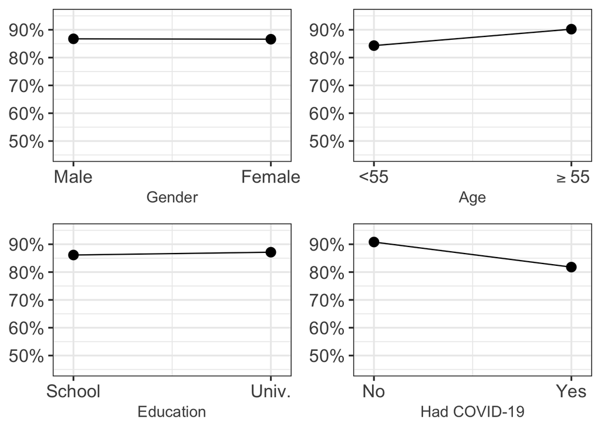

```r
set_theme(base = theme_bw(base_size = 15))
plot_vacc_news <- plot_model(news_mod_log_int, type = "eff", dot.size = 3.5)

lab_news <- c("No", "Yes")

ggarrange(plot_vacc_news$gender_grouped + labs(x = "Gender", y = NULL) + ggtitle(NULL) +
            scale_y_continuous(labels = scales::percent, limits = c(0.45, 0.95)) +
            scale_x_continuous(breaks = c(0, 1), labels = c("Male", "Female")) +
            theme(axis.title.x = element_text(size = 13)) + geom_line(),
          plot_vacc_news$age_dummy_grouped + labs(x = "Age", y = NULL) + ggtitle(NULL) +
            scale_y_continuous(labels = scales::percent, limits = c(0.45, 0.95)) +
            scale_x_continuous(breaks = c(0, 1), labels = c("<55", expression("">=55))) +
            theme(axis.title.x = element_text(size = 13)) + geom_line(),
          plot_vacc_news$education_grouped + labs(x = "Education", y = NULL) + ggtitle(NULL) +
            scale_y_continuous(labels = scales::percent, limits = c(0.45, 0.95)) +
            scale_x_continuous(breaks = c(0, 1), labels = c("School", "Univ.")) +
            theme(axis.title.x = element_text(size = 13)) + geom_line(),
          plot_vacc_news$cov_inf + labs(x = "Had COVID-19", y = NULL) + ggtitle(NULL) +
            scale_y_continuous(labels = scales::percent, limits = c(0.45, 0.95)) +
            scale_x_continuous(breaks = c(0, 1), labels = c("No", "Yes")) +
            theme(axis.title.x = element_text(size = 13)) + geom_line(), ncol = 2, nrow = 2)
```

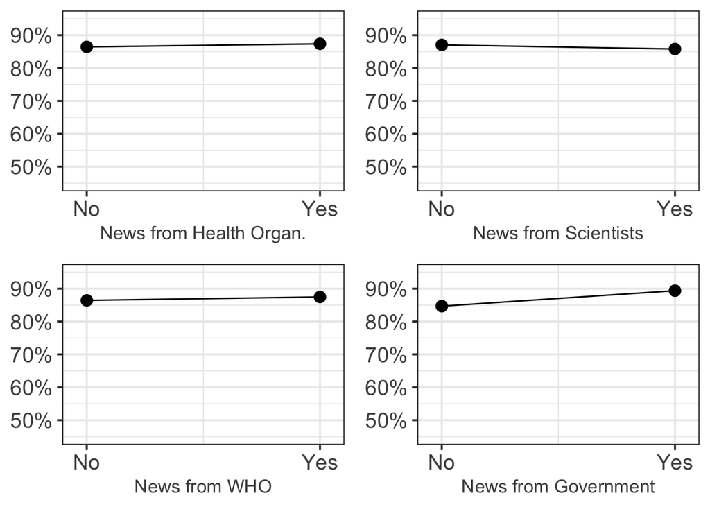

```r
ggarrange(plot_vacc_news$news_loc + labs(x="News from Health Organ.", y = NULL) + ggtitle(NULL) +
            scale_y_continuous(labels = scales::percent, limits = c(0.45, 0.95)) +
            scale_x_continuous(breaks = c(0, 1), labels = lab_news) +
            theme(axis.title.x = element_text(size = 13)) + geom_line(),
          plot_vacc_news$news_science + labs(x="News from Scientists", y=NULL) + ggtitle(NULL) +
            scale_y_continuous(labels = scales::percent, limits = c(0.45, 0.95)) +
            scale_x_continuous(breaks = c(0, 1), labels = lab_news) +
            theme(axis.title.x = element_text(size = 13)) + geom_line(),
          plot_vacc_news$news_who + labs(x = "News from WHO", y = NULL) + ggtitle(NULL) +
            scale_y_continuous(labels = scales::percent, limits = c(0.45, 0.95))+
            scale_x_continuous(breaks = c(0, 1), labels = lab_news) +
            theme(axis.title.x = element_text(size = 13)) + geom_line(),
          plot_vacc_news$news_gov+ labs(x = "News from Government", y = NULL) + ggtitle(NULL) +
            scale_y_continuous(labels = scales::percent, limits = c(0.45, 0.95)) +
            scale_x_continuous(breaks = c(0, 1), labels = lab_news)+
            theme(axis.title.x = element_text(size = 13)) + geom_line(), ncol = 2, nrow = 2)
```

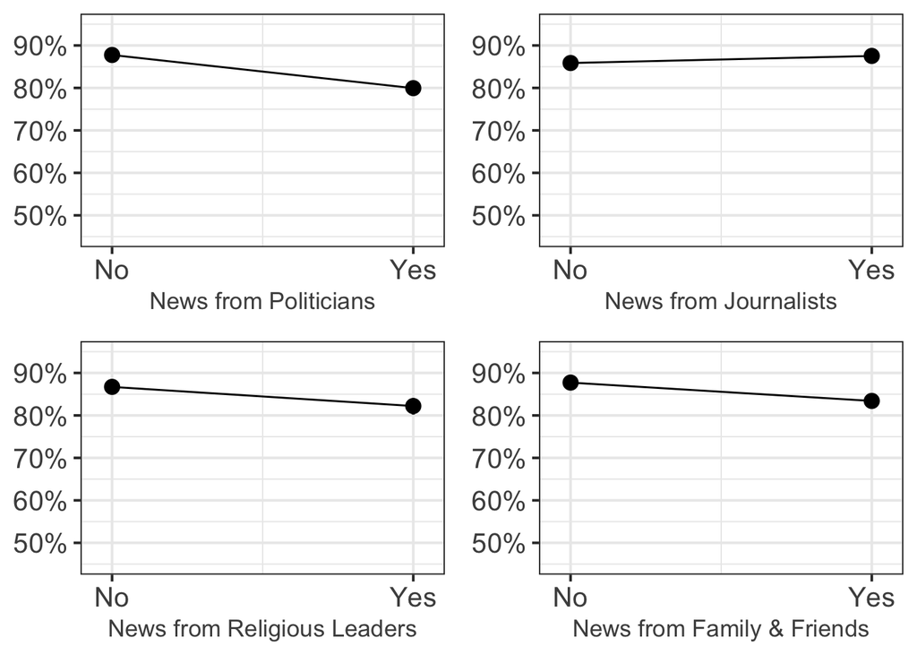

```r
ggarrange(plot_vacc_news$news_pol + labs(x = "News from Politicians", y = NULL) + ggtitle(NULL) +
            scale_y_continuous(labels = scales::percent, limits = c(0.45, 0.95)) +
            scale_x_continuous(breaks = c(0, 1), labels = lab_news) +
            theme(axis.title.x = element_text(size = 13)) + geom_line(),
          plot_vacc_news$news_journalist + labs(x = "News from Journalists", y = NULL) + ggtitle(NULL) +
            scale_y_continuous(labels = scales::percent, limits = c(0.45, 0.95)) +
            scale_x_continuous(breaks = c(0, 1), labels = lab_news)+
            theme(axis.title.x = element_text(size = 13)) + geom_line(),
          plot_vacc_news$news_religious + labs(x = "News from Religious Leaders", y = NULL) + ggtitle(NULL) +
            scale_y_continuous(labels = scales::percent, limits = c(0.45, 0.95)) +
            scale_x_continuous(breaks = c(0, 1), labels = lab_news)+
            theme(axis.title.x = element_text(size = 13)) + geom_line(),
          plot_vacc_news$news_fam + labs(x = "News from Family & Friends", y = NULL) + ggtitle(NULL) +
            scale_y_continuous(labels = scales::percent, limits = c(0.45, 0.95)) +
            scale_x_continuous(breaks = c(0, 1), labels = lab_news) +
            theme(axis.title.x = element_text(size = 13)) + geom_line(), ncol = 2, nrow = 2)
```

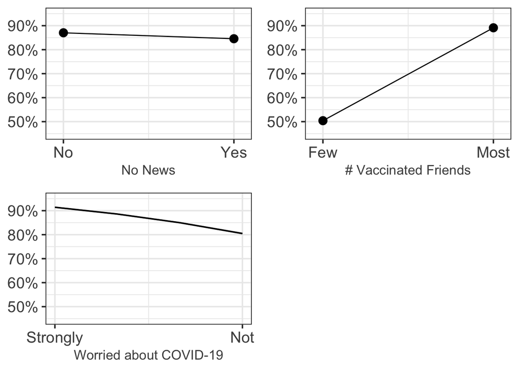

```r
ggarrange(plot_vacc_news$news_none + labs(x = "No News", y = NULL) + ggtitle(NULL) +
            scale_y_continuous(labels = scales::percent, limits = c(0.45, 0.95)) +
            scale_x_continuous(breaks = c(0, 1), labels = lab_news) +
            theme(axis.title.x = element_text(size = 13)) + geom_line(),
          plot_vacc_news$vacc_friends_grouped + labs(x = "# Vaccinated Friends", y=NULL) + ggtitle(NULL) +
            scale_y_continuous(labels = scales::percent, limits = c(0.45, 0.95)) +
            scale_x_continuous(breaks = c(0, 1), labels = c("Few", "Most")) +
            theme(axis.title.x = element_text(size = 13)) + geom_line(),
          plot_vacc_news$worry_cov + labs(x = "Worried about COVID-19", y=NULL) + ggtitle(NULL) +
            scale_y_continuous(labels = scales::percent, limits = c(0.45, 0.95)) +
            scale_x_continuous(breaks = c(1, 4), labels = c("Strongly", "Not")) +
            theme(axis.title.x = element_text(size = 13)) + geom_line(), ncol = 2, nrow = 2)
```

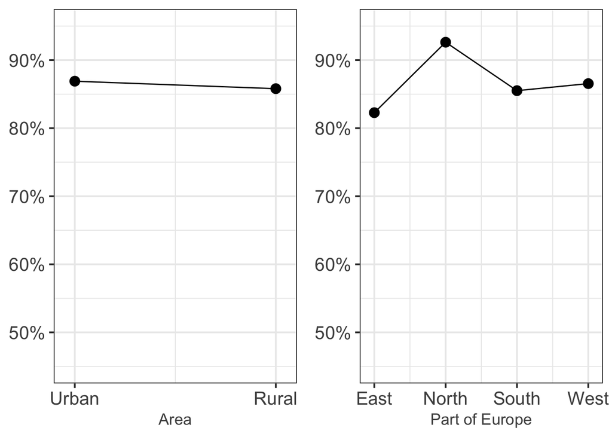

```r
ggarrange(plot_vacc_news$area_grouped + labs(x = "Area", y = NULL) + ggtitle(NULL) +
            scale_y_continuous(labels = scales::percent, limits = c(0.45, 0.95))+
            scale_x_continuous(breaks = c(0, 1), labels = c("Urban", "Rural")) +
            theme(axis.title.x = element_text(size = 13)) + geom_line(),
          plot_vacc_news$europe_part + labs(x = "Part of Europe", y=NULL) + ggtitle(NULL) +
            scale_y_continuous(labels = scales::percent, limits = c(0.45, 0.95)) +
            theme(axis.title.x = element_text(size = 13)) + geom_line(), ncol = 2)
```

Effect plot for interaction effects:

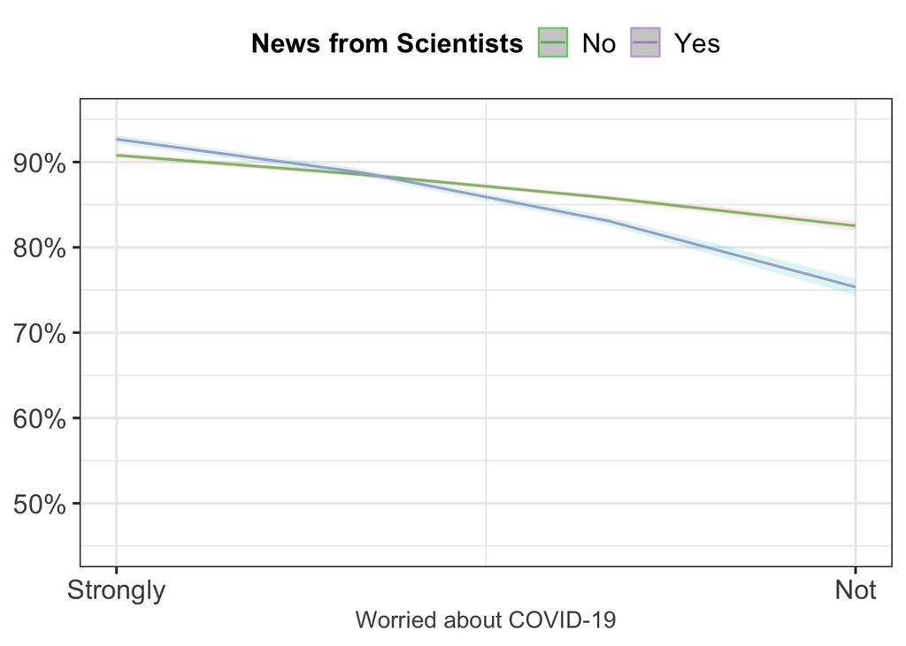

```r
plot_model(news_mod_log_int, type = "eff", terms = c("worry_cov", "news_science"), dot.size = 3.5) +
  scale_y_continuous(labels = scales::percent, limits = c(0.45, 0.95)) +
  scale_x_continuous(breaks = c(1, 4), labels = c("Strongly", "Not")) +
  labs(x = "Worried about COVID-19", y = NULL) +
  scale_color_brewer(name = "News from Scientists", labels = c("No", "Yes"), palette = "Accent") +
  ggtitle(NULL) +
  theme(legend.position = "top",
        axis.title.x = element_text(size = 13))
```

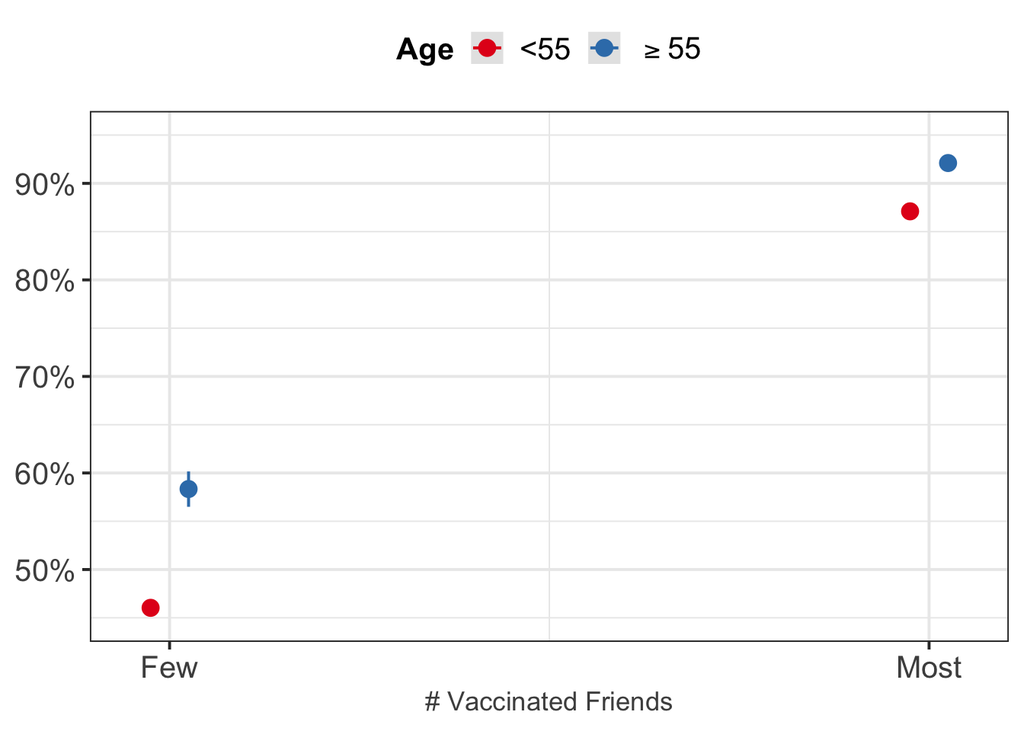

```r
plot_model(news_mod_log_int, type = "eff", terms = c("vacc_friends_grouped", "age_dummy_grouped"), dot.size = 3.5) +
  scale_y_continuous(labels = scales::percent, limits = c(0.45, 0.95)) +
  scale_x_continuous(breaks = c(0, 1), labels = c("Few", "Most")) +
  labs(x = "# Vaccinated Friends", y = NULL) +
  scale_color_brewer(name = "Age", labels = c("<55", expression("">=55)), palette = "Set1") +
  ggtitle(NULL) +
  theme(legend.position = "top",
        axis.title.x = element_text(size = 13))
```

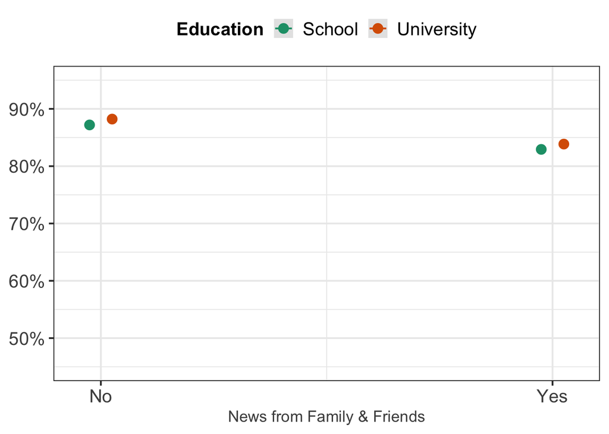

```r
plot_model(news_mod_log_int, type = "eff", terms = c("news_fam", "education_grouped"), dot.size = 3.5) +
  scale_y_continuous(labels = scales::percent, limits = c(0.45, 0.95)) +
  scale_x_continuous(breaks = c(0, 1), labels = lab_news) +
  labs(x = "News from Family & Friends", y = NULL) +
  scale_color_brewer(name = "Education", labels = c("School", "University"), palette = "Dark2") +
  ggtitle(NULL) +
  theme(legend.position = "top",
        axis.title.x = element_text(size = 13))
```

# Model with trust-variables as covariables

Model with ungrouped variables:

```r
trust_mod_log_full <- glm(vacc ~ trust_loc + trust_science + trust_who + trust_gov + trust_pol
                 + trust_journalist + trust_fam + trust_religious + gender + age_grouped + area
                 + education_grouped + cov_inf + worry_cov + vacc_friends_grouped + europe_part,
                 family = binomial(), data = dt_sept_eu)
summary(trust_mod_log_full)
```

```
##
## Call:
## glm(formula = vacc ~ trust_loc + trust_science + trust_who +
##     trust_gov + trust_pol + trust_journalist + trust_fam + trust_religious +
##     gender + age_grouped + area + education_grouped + cov_inf +
##     worry_cov + vacc_friends_grouped + europe_part, family = binomial(),
##     data = dt_sept_eu)
##
## Deviance Residuals:
##     Min       1Q   Median       3Q      Max
## -3.2310   0.1795   0.3022   0.5150   2.4458
##
## Coefficients:
##                       Estimate Std. Error z value Pr(>|z|)
## (Intercept)           -0.99944    0.07403 -13.501  < 2e-16 ***
## trust_loc2             0.33557    0.03270  10.262  < 2e-16 ***
## trust_loc3             0.78787    0.03971  19.838  < 2e-16 ***
## trust_science2        -0.15181    0.03913  -3.880 0.000105 ***
## trust_science3         0.26086    0.04514   5.779 7.50e-09 ***
## trust_who2             0.71802    0.02963  24.231  < 2e-16 ***
## trust_who3             1.19390    0.03831  31.163  < 2e-16 ***
## trust_gov2             0.61379    0.02570  23.879  < 2e-16 ***
## trust_gov3             0.99572    0.04245  23.454  < 2e-16 ***
## trust_pol2             0.22959    0.02743   8.371  < 2e-16 ***
## trust_pol3             0.29356    0.07710   3.808 0.000140 ***
## trust_journalist2      0.18592    0.02284   8.142 3.89e-16 ***
## trust_journalist3      0.17162    0.05893   2.912 0.003591 **
## trust_fam2            -0.37255    0.03117 -11.952  < 2e-16 ***
## trust_fam3            -0.59411    0.03615 -16.437  < 2e-16 ***
## trust_religious2      -0.29361    0.03143  -9.341  < 2e-16 ***
## trust_religious3      -0.34491    0.07442  -4.635 3.58e-06 ***
## gender                -0.02313    0.01988  -1.164 0.244588
## age_grouped2           0.48621    0.02245  21.656  < 2e-16 ***
## age_grouped3           1.12043    0.03910  28.658  < 2e-16 ***
## area2                  0.08089    0.02264   3.573 0.000353 ***
## area3                 -0.01797    0.02665  -0.674 0.500193
## education_grouped1    -0.01709    0.02022  -0.845 0.397844
## cov_inf1              -0.69063    0.03131 -22.059  < 2e-16 ***
## worry_cov             -0.14799    0.01049 -14.108  < 2e-16 ***
## vacc_friends_grouped1  1.76209    0.02538  69.437  < 2e-16 ***
## europe_partNorth       0.48296    0.03424  14.104  < 2e-16 ***
## europe_partSouth       0.10166    0.02654   3.831 0.000128 ***
## europe_partWest        0.05124    0.02683   1.910 0.056115 .
## ---
## Signif. codes:  0 '***' 0.001 '**' 0.01 '*' 0.05 '.' 0.1 ' ' 1
##
## (Dispersion parameter for binomial family taken to be 1)
##
##     Null deviance: 100008  on 107171  degrees of freedom
## Residual deviance:  70048  on 107143  degrees of freedom
##   (762507 Beobachtungen als fehlend gelöscht)
## AIC: 70106
##
## Number of Fisher Scoring iterations: 6
```

Model with grouped variables

```r
trust_mod_log_group <- glm(vacc ~ trust_loc_group + trust_science_group + trust_who_group + trust_gov_group
                          + trust_pol_group + trust_journalist_group + trust_fam_group + trust_religious_group
                          + gender_grouped + age_dummy_grouped + area_grouped + education_grouped + cov_inf
                          + worry_cov + vacc_friends_grouped + europe_part,
                          family = binomial(), data = dt_sept_eu)
summary(trust_mod_log_group)
```

```
##
## Call:
## glm(formula = vacc ~ trust_loc_group + trust_science_group +
##     trust_who_group + trust_gov_group + trust_pol_group + trust_journalist_group +
##     trust_fam_group + trust_religious_group + gender_grouped +
##     age_dummy_grouped + area_grouped + education_grouped + cov_inf +
##     worry_cov + vacc_friends_grouped + europe_part, family = binomial(),
##     data = dt_sept_eu)
##
## Deviance Residuals:
##     Min       1Q   Median       3Q      Max
## -2.9325   0.2459   0.3562   0.4997   2.5417
##
## Coefficients:
##                         Estimate Std. Error z value Pr(>|z|)
## (Intercept)             -0.82013    0.06352 -12.911  < 2e-16 ***
## trust_loc_group1         0.50499    0.03279  15.402  < 2e-16 ***
## trust_science_group1    -0.08620    0.03977  -2.167  0.03022 *
## trust_who_group1         0.94306    0.02935  32.130  < 2e-16 ***
## trust_gov_group1         0.81260    0.02525  32.180  < 2e-16 ***
## trust_pol_group1         0.44202    0.02592  17.055  < 2e-16 ***
## trust_journalist_group1  0.24105    0.02217  10.872  < 2e-16 ***
## trust_fam_group1        -0.47481    0.03041 -15.613  < 2e-16 ***
## trust_religious_group1  -0.39689    0.02925 -13.568  < 2e-16 ***
## gender_grouped1         -0.10747    0.01969  -5.457 4.84e-08 ***
## age_dummy_grouped1       0.64486    0.02264  28.486  < 2e-16 ***
## area_grouped1           -0.06819    0.02409  -2.830  0.00465 **
## education_grouped1       0.09156    0.01969   4.651 3.31e-06 ***
## cov_inf1                -0.70921    0.02933 -24.179  < 2e-16 ***
## worry_cov               -0.18011    0.01033 -17.441  < 2e-16 ***
## vacc_friends_grouped1    1.88438    0.02501  75.360  < 2e-16 ***
## europe_partNorth         0.67793    0.03342  20.284  < 2e-16 ***
## europe_partSouth         0.21620    0.02605   8.299  < 2e-16 ***
## europe_partWest          0.12534    0.02635   4.757 1.97e-06 ***
## ---
## Signif. codes:  0 '***' 0.001 '**' 0.01 '*' 0.05 '.' 0.1 ' ' 1
##
## (Dispersion parameter for binomial family taken to be 1)
##
##     Null deviance: 99702  on 106937  degrees of freedom
## Residual deviance: 72983  on 106919  degrees of freedom
##   (762741 Beobachtungen als fehlend gelöscht)
## AIC: 73021
##
## Number of Fisher Scoring iterations: 5
```

Model with grouped variables and interactions:

```r
trust_mod_log_int <- glm(vacc ~ trust_loc_group + trust_science_group + trust_who_group + trust_gov_group
                         + trust_pol_group + trust_journalist_group + trust_fam_group + trust_religious_group
                         + gender_grouped + age_dummy_grouped + area_grouped + education_grouped + cov_inf
                         + worry_cov + vacc_friends_grouped + europe_part + age_dummy_grouped:trust_religious_group
                         + education_grouped:trust_gov_group + gender_grouped:trust_loc_group,
                        family = binomial(), data = dt_sept_eu)
summary(trust_mod_log_int)
```

```
##
## Call:
## glm(formula = vacc ~ trust_loc_group + trust_science_group +
##     trust_who_group + trust_gov_group + trust_pol_group + trust_journalist_group +
##     trust_fam_group + trust_religious_group + gender_grouped +
##     age_dummy_grouped + area_grouped + education_grouped + cov_inf +
##     worry_cov + vacc_friends_grouped + europe_part + age_dummy_grouped:trust_religious_group +
##     education_grouped:trust_gov_group + gender_grouped:trust_loc_group,
##     family = binomial(), data = dt_sept_eu)
##
## Deviance Residuals:
##     Min       1Q   Median       3Q      Max
## -2.9907   0.2334   0.3595   0.5007   2.5645
##
## Coefficients:
##                                             Estimate Std. Error z value
## (Intercept)                               -0.8044791  0.0688787 -11.680
## trust_loc_group1                           0.5662888  0.0433461  13.064
## trust_science_group1                      -0.0815328  0.0398284  -2.047
## trust_who_group1                           0.9382418  0.0293600  31.957
## trust_gov_group1                           0.7556098  0.0332549  22.722
## trust_pol_group1                           0.4448368  0.0259445  17.146
## trust_journalist_group1                    0.2432379  0.0221808  10.966
## trust_fam_group1                          -0.4620099  0.0303889 -15.203
## trust_religious_group1                    -0.4958520  0.0310236 -15.983
## gender_grouped1                           -0.0001757  0.0483164  -0.004
## age_dummy_grouped1                         0.4037173  0.0328252  12.299
## area_grouped1                             -0.0662756  0.0240938  -2.751
## education_grouped1                         0.0223474  0.0318746   0.701
## cov_inf1                                  -0.6956745  0.0294405 -23.630
## worry_cov                                 -0.1814915  0.0103310 -17.568
## vacc_friends_grouped1                      1.8820203  0.0250354  75.174
## europe_partNorth                           0.6803876  0.0334538  20.338
## europe_partSouth                           0.2212787  0.0260743   8.486
## europe_partWest                            0.1272325  0.0263485   4.829
## trust_religious_group1:age_dummy_grouped1  0.4450408  0.0450912   9.870
## trust_gov_group1:education_grouped1        0.1042633  0.0397905   2.620
## trust_loc_group1:gender_grouped1          -0.1245671  0.0525706  -2.370
##                                           Pr(>|z|)
## (Intercept)                                < 2e-16 ***
```

[output cut: 17 more lines]

```
## europe_partWest                           1.37e-06 ***
## trust_religious_group1:age_dummy_grouped1  < 2e-16 ***
## trust_gov_group1:education_grouped1        0.00879 **
## trust_loc_group1:gender_grouped1           0.01781 *
## ---
## Signif. codes:  0 '***' 0.001 '**' 0.01 '*' 0.05 '.' 0.1 ' ' 1
##
## (Dispersion parameter for binomial family taken to be 1)
##
##     Null deviance: 99702  on 106937  degrees of freedom
## Residual deviance: 72874  on 106916  degrees of freedom
##   (762741 Beobachtungen als fehlend gelöscht)
## AIC: 72918
##
## Number of Fisher Scoring iterations: 5
```

Effect plots:

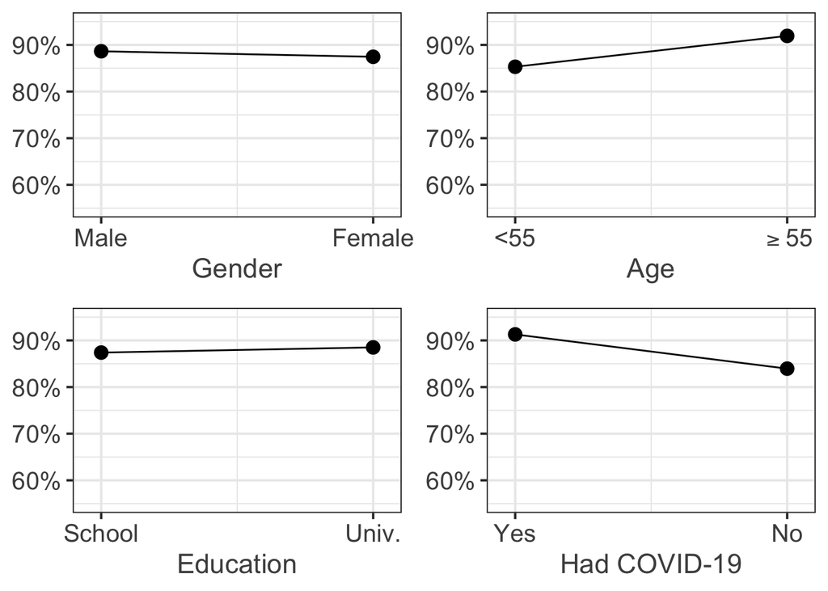

```r
set_theme(base = theme_bw(base_size = 15))
plot_vacc_trust <- plot_model(trust_mod_log_int, type = "eff", dot.size = 3.5)

lab_trust <- c("No Trust", "Trust")

ggarrange(plot_vacc_trust$gender_grouped + labs(x = "Gender", y = NULL) + ggtitle(NULL) +
            scale_y_continuous(labels = scales::percent, limits = c(0.55, 0.95)) +
            scale_x_continuous(breaks = c(0, 1), labels = c("Male", "Female")) + geom_line(),
          plot_vacc_trust$age_dummy_grouped + labs(x = "Age", y = NULL) + ggtitle(NULL) +
            scale_y_continuous(labels = scales::percent, limits = c(0.55, 0.95)) +
            scale_x_continuous(breaks = c(0, 1), labels = c("<55", expression("">=55))) + geom_line(),
          plot_vacc_trust$education_grouped + labs(x = "Education", y = NULL) + ggtitle(NULL) +
            scale_y_continuous(labels = scales::percent, limits = c(0.55, 0.95)) +
            scale_x_continuous(breaks = c(0, 1), labels = c("School", "Univ.")) + geom_line(),
          plot_vacc_trust$cov_inf + labs(x = "Had COVID-19", y = NULL) + ggtitle(NULL) +
            scale_y_continuous(labels = scales::percent, limits = c(0.55, 0.95)) +
            scale_x_continuous(breaks = c(0, 1), labels = c("Yes", "No")) + geom_line(), ncol = 2, nrow = 2)
```

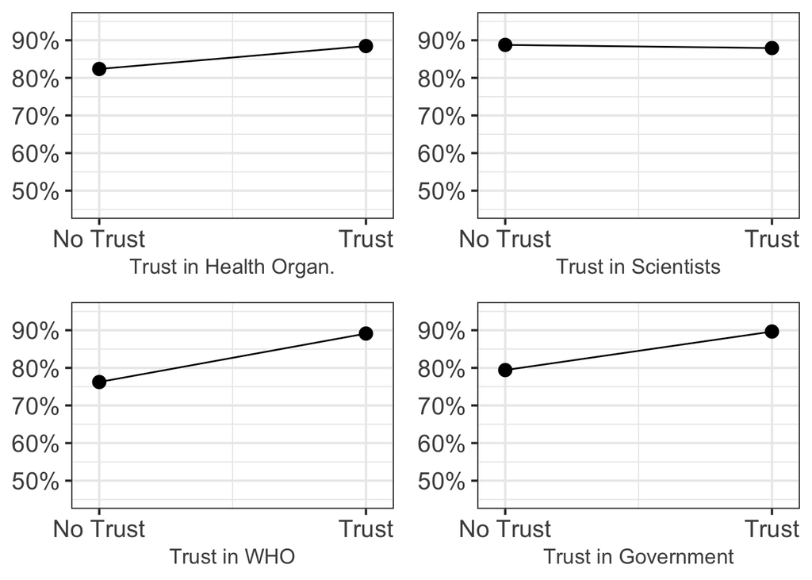

```r
ggarrange(plot_vacc_trust$trust_loc_group + labs(x="Trust in Health Organ.", y = NULL) + ggtitle(NULL) +
            scale_y_continuous(labels = scales::percent, limits = c(0.45, 0.95)) +
            scale_x_continuous(breaks = c(0, 1), labels = lab_trust)+
            theme(axis.title.x = element_text(size = 13)) + geom_line(),
          plot_vacc_trust$trust_science_group + labs(x="Trust in Scientists", y=NULL) + ggtitle(NULL) +
            scale_y_continuous(labels = scales::percent, limits = c(0.45, 0.95)) +
            scale_x_continuous(breaks = c(0, 1), labels = lab_trust) +
            theme(axis.title.x = element_text(size = 13)) + geom_line(),
          plot_vacc_trust$trust_who_group + labs(x = "Trust in WHO", y = NULL) + ggtitle(NULL) +
            scale_y_continuous(labels = scales::percent, limits = c(0.45, 0.95))+
            scale_x_continuous(breaks = c(0, 1), labels = lab_trust) +
            theme(axis.title.x = element_text(size = 13)) + geom_line(),
          plot_vacc_trust$trust_gov_group + labs(x = "Trust in Government", y = NULL) + ggtitle(NULL) +
            scale_y_continuous(labels = scales::percent, limits = c(0.45, 0.95)) +
            scale_x_continuous(breaks = c(0, 1), labels = lab_trust)+
            theme(axis.title.x = element_text(size = 13)) + geom_line(), ncol = 2, nrow = 2)
```

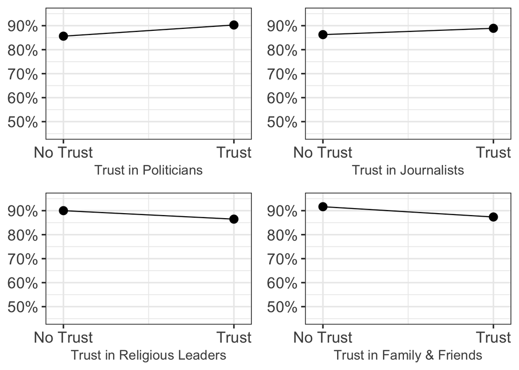

```r
ggarrange(plot_vacc_trust$trust_pol_group + labs(x = "Trust in Politicians", y = NULL) + ggtitle(NULL) +
            scale_y_continuous(labels = scales::percent, limits = c(0.45, 0.95)) +
            scale_x_continuous(breaks = c(0, 1), labels = lab_trust) +
            theme(axis.title.x = element_text(size = 13)) + geom_line(),
          plot_vacc_trust$trust_journalist_group + labs(x = "Trust in Journalists", y = NULL) + ggtitle(NULL) +
            scale_y_continuous(labels = scales::percent, limits = c(0.45, 0.95)) +
            scale_x_continuous(breaks = c(0, 1), labels = lab_trust) +
            theme(axis.title.x = element_text(size = 13)) + geom_line(),
          plot_vacc_trust$trust_religious_group + labs(x = "Trust in Religious Leaders", y = NULL) + ggtitle(NULL) +
            scale_y_continuous(labels = scales::percent, limits = c(0.45, 0.95)) +
            scale_x_continuous(breaks = c(0, 1), labels = lab_trust)+
            theme(axis.title.x = element_text(size = 13)) + geom_line(),
          plot_vacc_trust$trust_fam_group + labs(x = "Trust in Family & Friends", y = NULL) + ggtitle(NULL) +
            scale_y_continuous(labels = scales::percent, limits = c(0.45, 0.95)) +
            scale_x_continuous(breaks = c(0, 1), labels = lab_trust) +
            theme(axis.title.x = element_text(size = 13)) + geom_line(), ncol = 2, nrow = 2)
```

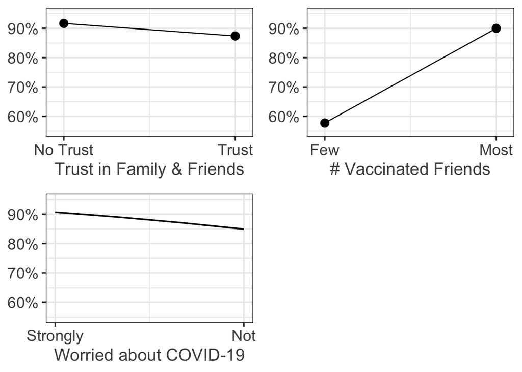

```r
ggarrange(plot_vacc_trust$trust_fam_group + labs(x = "Trust in Family & Friends", y = NULL) + ggtitle(NULL) +
            scale_y_continuous(labels = scales::percent, limits = c(0.55, 0.95)) +
            scale_x_continuous(breaks = c(0, 1), labels = lab_trust) + geom_line(),
          plot_vacc_trust$vacc_friends_grouped + labs(x = "# Vaccinated Friends", y=NULL) + ggtitle(NULL) +
            scale_y_continuous(labels = scales::percent, limits = c(0.55, 0.95)) +
            scale_x_continuous(breaks = c(0, 1), labels = c("Few", "Most")) + geom_line(),
          plot_vacc_trust$worry_cov + labs(x = "Worried about COVID-19", y=NULL) + ggtitle(NULL) +
            scale_y_continuous(labels = scales::percent, limits = c(0.55, 0.95)) +
            scale_x_continuous(breaks = c(1, 4), labels = c("Strongly", "Not")) + geom_line())
```

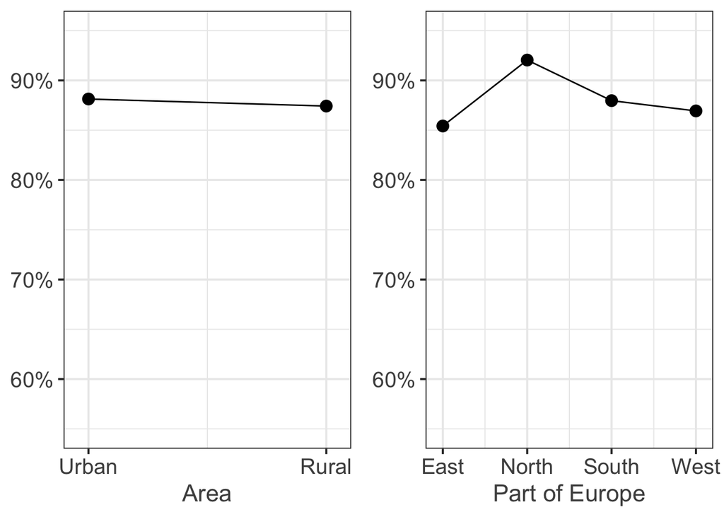

```r
ggarrange(plot_vacc_trust$area_grouped + labs(x = "Area", y = NULL) + ggtitle(NULL) +
            scale_y_continuous(labels = scales::percent, limits = c(0.55, 0.95))+
            scale_x_continuous(breaks = c(0, 1), labels = c("Urban", "Rural")) + geom_line(),
          plot_vacc_trust$europe_part + labs(x = "Part of Europe", y=NULL) + ggtitle(NULL) +
            scale_y_continuous(labels = scales::percent, limits = c(0.55, 0.95)) + geom_line(),
          ncol = 2)
```

Effect Plots for interaction effects:

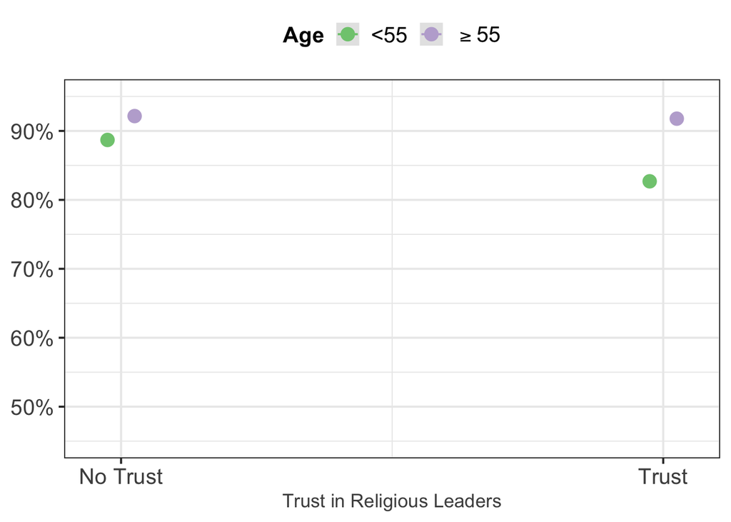

```r
plot_model(trust_mod_log_int, type = "eff", terms = c("trust_religious_group", "age_dummy_grouped"), dot.size = 4) +
  scale_y_continuous(labels = scales::percent, limits = c(0.45, 0.95)) +
  scale_x_continuous(breaks = c(0, 1), labels = lab_trust) +
  labs(x = "Trust in Religious Leaders", y = NULL) +
  scale_color_brewer(name = "Age", labels = c("<55", expression("">=55)), palette = "Accent") +
  ggtitle(NULL) +
  theme(legend.position = "top",
        axis.title.x = element_text(size = 13))
```

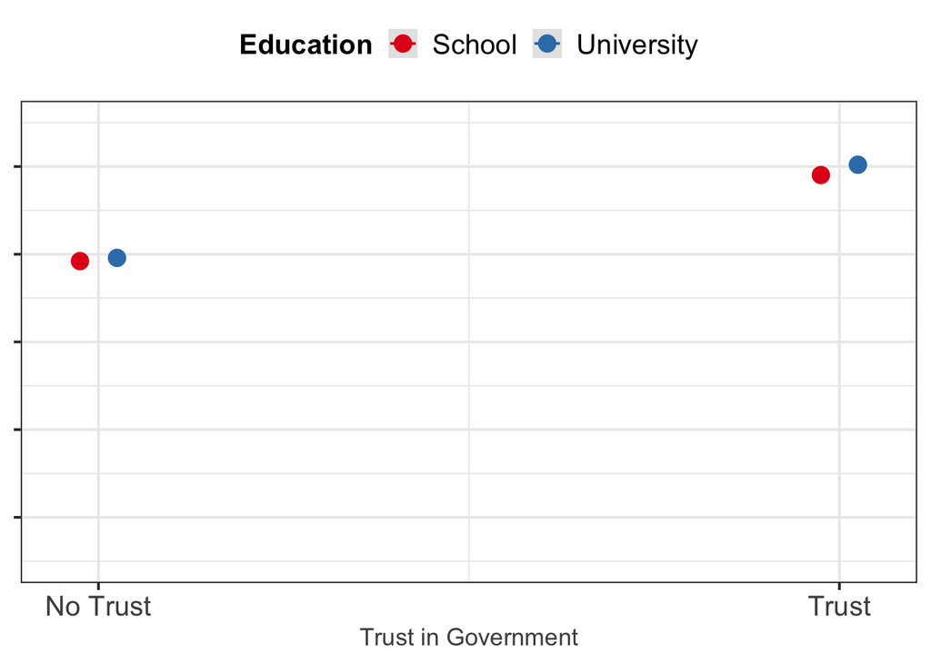

```r
plot_model(trust_mod_log_int, type = "eff", terms = c("trust_gov_group", "education_grouped"), dot.size = 4) +
  scale_y_continuous(labels = NULL, limits = c(0.45, 0.95)) +
  scale_x_continuous(breaks = c(0, 1), labels = lab_trust) +
  labs(x = "Trust in Government", y = NULL) +
  scale_color_brewer(name = "Education", labels = c("School", "University"), palette = "Set1") +
  ggtitle(NULL) +
  theme(legend.position = "top",
        axis.title.x = element_text(size = 13))
```

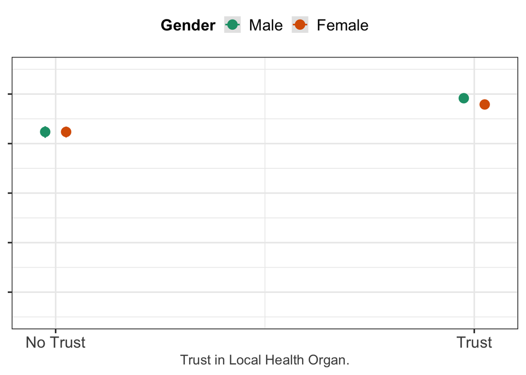

```r
plot_model(trust_mod_log_int, type = "eff", terms = c("trust_loc_group", "gender_grouped"), dot.size = 4) +
  scale_y_continuous(labels = NULL, limits = c(0.45, 0.95)) +
  scale_x_continuous(breaks = c(0, 1), labels = lab_trust) +
  labs(x = "Trust in Local Health Organ.", y = NULL) +
  scale_color_brewer(name = "Gender", labels = c("Male", "Female"), palette = "Dark2") +
  ggtitle(NULL) +
  theme(legend.position = "top",
        axis.title.x = element_text(size = 13))
```

# Booster Vaccination

Create dataset for february (created folders for different versions in february)

```r
## 1st-13th February
# list_of_files_1 <- list.files(path = "data_feb1", recursive = TRUE, pattern = "\\.csv$", full.names = TRUE)
# df1 <- read_csv(list_of_files_1, id = "file_name")
# df1$RecordedDate <- as.character(df1$RecordedDate)
#
## 14th-23rd February
# list_of_files_2 <- list.files(path = "data_feb2", recursive = TRUE, pattern = "\\.csv$", full.names = TRUE)
# df2 <- read_csv(list_of_files_2, id = "file_name")
# df2$RecordedDate <- as.character(df2$RecordedDate)
#
## 24th-26th February
# list_of_files_3 <- list.files(path = "data_feb3", recursive = TRUE, pattern = "\\.csv$", full.names = TRUE)
# df3 <- read_csv(list_of_files_3, id = "file_name")
# df3$RecordedDate <- as.character(df3$RecordedDate)
#
## 27th-28th February
# list_of_files_4 <- list.files(path = "data_feb4", recursive = TRUE, pattern = "\\.csv$", full.names = TRUE)
# df4 <- read_csv(list_of_files_4, id = "file_name")
# df4$RecordedDate <- as.character(df4$RecordedDate)
#
# df <- bind_rows(df1, df2, df3, df4)
#
# library(data.table)
# fwrite(df, "february_dt.csv")
```

Read and prepare data of february

```r
dt_feb <- read.csv("february_dt.csv")
dt_feb_eu <- dt_feb %>%
  filter(A2_2_1 %in% country_num) %>%
  dplyr::select(survey_region, B0a, A2_2_1, B7, B8a, V1, V2, V15a, V3a, C0a_1, C0a_2, C0a_3, C0a_4, C0a_5, C0a_6,
                C0a_7, G1, H3, I5_1, I5_2, I5_3, I5_4, I5_5, I5_6, I5_7, I5_8, I5_9, I6_1, I6_2, I6_3, I6_4, I6_5,
                I6_6, I6_7, I6_8, E3, V11, E4, E8, E2) %>%
  mutate_all(na_if, -99) %>%
  mutate_all(na_if, -88) %>%
  mutate_all(na_if, -77)
```

How many people answered the question “How many COVID-19 vaccinations have you received?”

```r
table(dt_feb_eu$V2)
```

```
##
##  1  2  3
##  4 24  1
```